# Laboratorio di Analisi dei Dati con R

Soluzioni laboratorio modulo 2

Author

Ottavia Epifania

# 1 Case Study A: Test di selezione universitario

Il case study richiede di eseguire delle procedure di analisi dei dati su un insieme di variabili associate a 70 candidati di un corso di laurea del nord-est.

## 1.1 Esercizio 1

Scaricare il file `datiTestCR2005.csv` (moodle del corso) e caricarlo nella variabile (data frame) `datitest` in R. Il file contiene un database con 70 osservazioni misurate su 7 variabili distinte:

- `DIPAA` indica l’anno in cui lo studente ha ottenuto il suo diploma di scuola superiore;
- `VOTO` è il voto di diploma ottenuto dallo studente (espresso in centesimi, voto minimo = 60);
- `SESSO` codifica il sesso dello studente (1: maschio, 2: femmina);
- `D1` punteggio complessivo ad un test per la misura del ragionamento deduttivo [0,17];
- `D2` punteggio complessivo ad un test per la misura del ragionamento spaziale [0,20];
- `D3` punteggio complessivo ad un test per la misura del pensiero creativo [0,4];
- `D4` punteggio complessivo ad un test per la comprensione di testi, grafici e tabelle [0,12].

```r
datitest <- read.csv2("data/datiTestCR2005.csv")
```

```
Warning in scan(file = file, what = what, sep = sep, quote = quote, dec = dec,
: embedded nul trovati in input
```

Appare un warning relativo all’importazione del file. Per controllare se tutto però è andato bene:

```r
head(datitest)
```

```
  DIPAA VOTO SESSO D1 D2 D3 D4
1  2005   63     2  9 17  2 11
2  1999   80     1 12 18  2  8
3  2005   64     1 11 17  2  5
4  2005   95     1  9 14  3  3
5  2005   93     2 13 18  4 12
6  2005   65     2  7 11  0 12
```

Si eseguano i seguenti controlli.

1. Verificare che **tutte** le variabili non contengano dei valori scorretti.

```r
# Voto
datitest$VOTO >= 60 & datitest$VOTO <= 100
```

```
 [1]  TRUE  TRUE  TRUE  TRUE  TRUE  TRUE  TRUE  TRUE  TRUE  TRUE  TRUE  TRUE
[13]  TRUE  TRUE  TRUE  TRUE  TRUE  TRUE  TRUE  TRUE  TRUE  TRUE  TRUE  TRUE
[25]  TRUE  TRUE  TRUE  TRUE  TRUE  TRUE  TRUE  TRUE  TRUE  TRUE  TRUE  TRUE
[37]  TRUE  TRUE  TRUE  TRUE  TRUE  TRUE  TRUE  TRUE  TRUE  TRUE  TRUE  TRUE
[49]  TRUE FALSE  TRUE  TRUE  TRUE  TRUE  TRUE  TRUE  TRUE  TRUE  TRUE  TRUE
[61]  TRUE  TRUE  TRUE  TRUE  TRUE  TRUE  TRUE  TRUE  TRUE  TRUE
```

Attenzione! c’è un valore che `FALSE`, va trovato con la funzione `which()`

```r
which(datitest$VOTO < 60 | datitest$VOTO > 100)
```

```
[1] 50
```

```r
# che voto ha preso?
index = which(datitest$VOTO < 60 | datitest$VOTO > 100)
datitest$VOTO[index]
```

```
[1] 39
```

```r
# sesso
datitest$SESSO ==1 | datitest$SESSO == 2
```

```
 [1] TRUE TRUE TRUE TRUE TRUE TRUE TRUE TRUE TRUE TRUE TRUE TRUE TRUE TRUE TRUE
[16] TRUE TRUE TRUE TRUE TRUE TRUE TRUE TRUE TRUE TRUE TRUE TRUE TRUE TRUE TRUE
[31] TRUE TRUE TRUE TRUE TRUE TRUE TRUE TRUE TRUE TRUE TRUE TRUE TRUE TRUE TRUE
[46] TRUE TRUE TRUE TRUE TRUE TRUE TRUE TRUE TRUE TRUE TRUE TRUE TRUE TRUE TRUE
[61] TRUE TRUE TRUE TRUE TRUE TRUE TRUE TRUE TRUE TRUE
```

```r
# per fare prima: sappiamo che ci sono 70 osservazioni. Se tutti i risultati del
# test sono veri, il risultato sarà 70, per cui:
sum(datitest$SESSO ==1 | datitest$SESSO == 2) == nrow(datitest)
```

```
[1] TRUE
```

```r
# controlla le altre varibaili

sum((datitest$D1>=0) & (datitest$D1<=17)) == nrow(datitest)
```

```
[1] TRUE
```

```r
sum((datitest$D2>=0) & (datitest$D2<=20)) == nrow(datitest)
```

```
[1] TRUE
```

```r
sum((datitest$D3>=0) & (datitest$D3<=4)) == nrow(datitest)
```

```
[1] TRUE
```

```r
sum((datitest$D4>=0) & (datitest$D4<=12))== nrow(datitest)
```

```
[1] TRUE
```

2. Se vi sono delle variabili che presentano dei valori scorretti, sostituire le osservazioni in `datitest` che presentano tali valori scorretti con la media della variabile di riferimento, escludendo dal calcolo della media i dati scorretti.

```r
# Setp1: calcolare la media della variabile voto SENZA l'osservazione sbagliata
media_corretta = mean(datitest$VOTO[-index])
# Setp 2: sostituire il valore
datitest$VOTO[index] = media_corretta
# step 3: controllare che abbia funzionato:
which(datitest$VOTO < 60 | datitest$VOTO > 100)
```

```
integer(0)
```

3. Visualizzare le statistiche descrittive di base (`summary()`) delle variabili VOTO e D1, …, D4.

```r
summary(datitest[, c("VOTO", "D1", "D2", "D3", "D4")])
```

```
      VOTO              D1              D2              D3
 Min.   : 60.00   Min.   : 5.00   Min.   : 7.00   Min.   :0.000
 1st Qu.: 69.25   1st Qu.: 9.00   1st Qu.:13.00   1st Qu.:1.000
 Median : 78.84   Median :11.00   Median :14.00   Median :2.000
 Mean   : 78.68   Mean   :10.79   Mean   :14.36   Mean   :2.057
 3rd Qu.: 87.00   3rd Qu.:13.00   3rd Qu.:17.00   3rd Qu.:3.000
 Max.   :100.00   Max.   :15.00   Max.   :20.00   Max.   :4.000
       D4
 Min.   : 3.000
 1st Qu.: 9.000
 Median :10.000
 Mean   : 9.686
 3rd Qu.:11.000
 Max.   :12.000
```

4. Costruire ed assegnare una variabile `votomedioM` che contiene il voto medio dei candidati maschi. Creare un’analoga variabile `votomedioF` per le femmine.

```r
votoM = datitest$VOTO[datitest$SESSO == 1]
votomedioM = mean(votoM)

votoF = datitest$VOTO[datitest$SESSO == 2]
votomedioF = mean(votoF)
```

5. Verificare se il voto medio delle femmine è superiore a quello dei maschi.

```r
votomedioF > votomedioM
```

```
[1] TRUE
```

6. Verificare se la deviazione standard del voto delle femmine è superiore a quella dei maschi.

```r
sdvotoM = sd(votoM)
sdvotoF = sd(votoF)

sdvotoF > sdvotoM
```

```
[1] TRUE
```

7. Verificare se il voto medio dei diplomati nel 2005 è superiore rispetto a quello dei diplomati nel 2004.

```r
voto2005 = datitest$VOTO[datitest$DIPAA == 2005]
voto2004 = datitest$VOTO[datitest$DIPAA == 2004]

media2005 = mean(voto2005)
media2004 = mean(voto2004)
media2005 > media2004
```

```
[1] TRUE
```

8. Verificare se il voto medio dei diplomati maschi nel 2005 è superiore rispetto a quello dei diplomati maschi nel 2004.

```r
M2005 = datitest$VOTO[datitest$DIPAA==2005 & datitest$SESSO==1]
M2004 = datitest$VOTO[datitest$DIPAA==2004 & datitest$SESSO==1]

media_m2005 = mean(M2005)
media_m2004 = mean(M2004)

media_m2005 > media_m2004
```

```
[1] TRUE
```

9. Verificare se il punteggio medio del ragionamento spaziale nei maschi è superiore rispetto a quello delle femmine.

```r
votomedioD2M <- mean(datitest$D2[datitest$SESSO==1])
votomedioD2F <- mean(datitest$D2[datitest$SESSO==2])

votomedioD2M > votomedioD2F
```

```
[1] TRUE
```

10. Verificare se il punteggio medio del ragionamento deduttivo nei maschi è superiore rispetto a quello delle femmine.

```r
votomedioD1M <- mean(datitest$D1[datitest$SESSO==1])
votomedioD1F <- mean(datitest$D1[datitest$SESSO==2])

votomedioD1M > votomedioD1F
```

```
[1] FALSE
```

11. Verificare se il punteggio medio del pensiero creativo nelle femmine è superiore rispetto a quello dei maschi.

```r
votomedioD3M <- mean(datitest$D3[datitest$SESSO==1])
votomedioD3F <- mean(datitest$D3[datitest$SESSO==2])

votomedioD3M < votomedioD3F
```

```
[1] FALSE
```

12. Verificare se il punteggio medio del ragionamento deduttivo nei maschi che hanno avuto un voto di diploma superiore a 80 è superiore rispetto a quello delle femmine con voto di diploma superiore a 90.

```r
votomedioD1Ms80 <- mean(datitest$D1[datitest$SESSO==1 & datitest$VOTO>80])
votomedioD1Fs90 <- mean(datitest$D1[datitest$SESSO==2 & datitest$VOTO>90])

votomedioD1Ms80 > votomedioD1Fs90
```

```
[1] FALSE
```

13. Verificare se il punteggio medio del ragionamento deduttivo nei maschi che hanno avuto un voto di diploma superiore a 80 e che hanno avuto un punteggio inferiore a 2 nel test per la misura del pensiero creativo è superiore rispetto a quello delle femmine con voto di diploma superiore a 85.

```r
mediaF85 = mean(datitest$VOTO[datitest$SESSO == 2 & datitest$VOTO > 85])
maschi = datitest[datitest$SESSO == 1, ]
mediaM80 = mean(maschi[maschi$D3 < 2 & maschi$VOTO > 80, "D1"])
mediaM80 > mediaF85
```

```
[1] FALSE
```

14. Visualizzare la distribuzione del voto di diploma attraverso un istogramma.

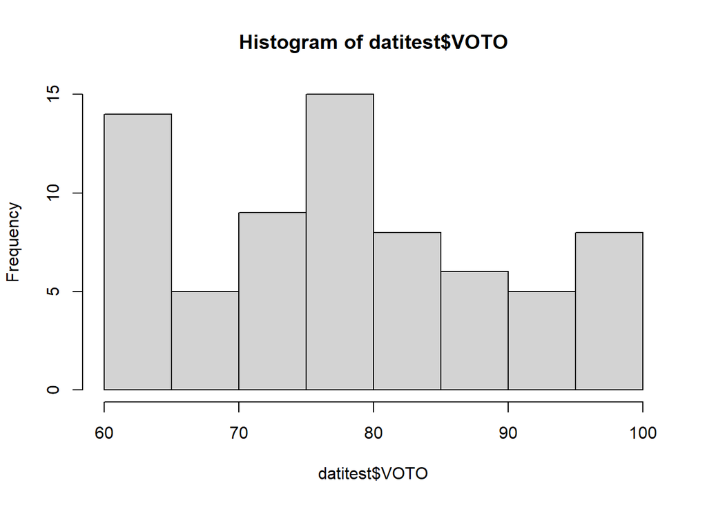

```r
hist(datitest$VOTO)
```

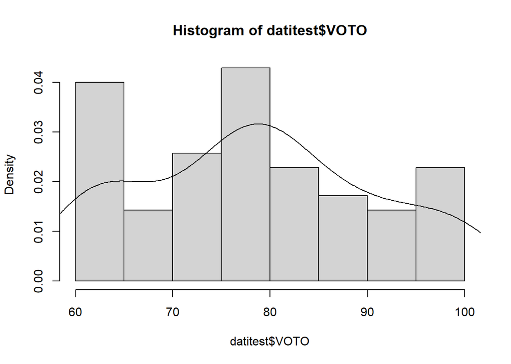

```r
hist(datitest$VOTO, freq = FALSE)
lines(density(datitest$VOTO))
```

15. **Nota 1**: utilizzando il comando `par(mfrow=c(n1,n2))` è possibile cambiare i parametri grafici perché appaiano più grafici. Ad esempio, `par(mfrow=c(2,3))` produce una finestra suddivisa in due righe e tre colonne, ogni cella della finestra puo contenere un grafico diverso.
16. Produrre due boxplot dei voti, uno per i maschi ed uno per le femmine. Devono apparire nello stesso grafico (usare il comando `par(mfrow=c(n1,n2))`)

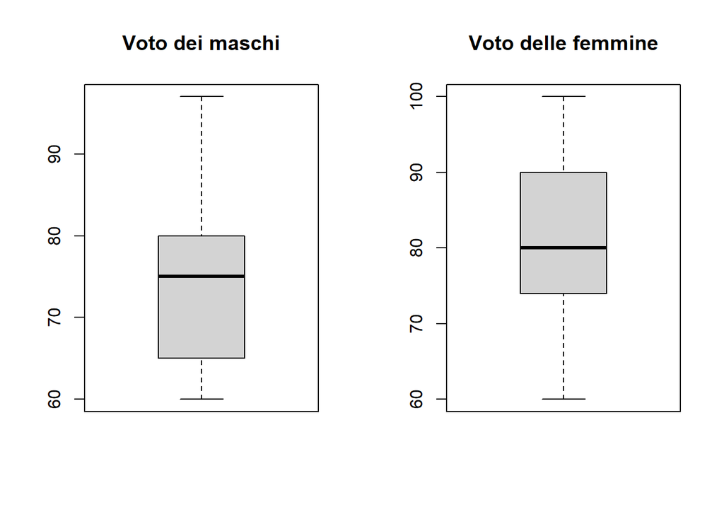

```r
par(mfrow=c(1,2))
boxplot(datitest$VOTO[datitest$SESSO ==1], main = "Voto dei maschi")
boxplot(datitest$VOTO[datitest$SESSO ==2], main = "Voto delle femmine")
```

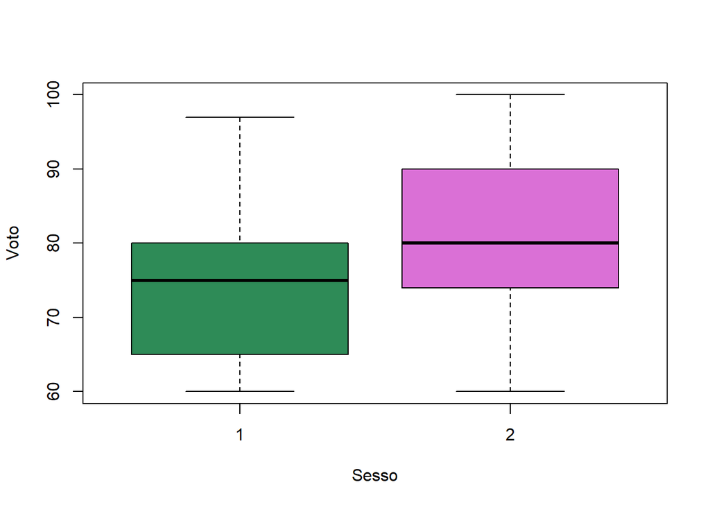

```r
par(mfrow=c(1,1)) # riporta normale la finestra
boxplot(datitest$VOTO ~ datitest$SESSO,
        col = c("seagreen", "orchid"),
        xlab = "Sesso", ylab="Voto")
```

17. Creare quattro grafici di boxplot (disponendoli in una unica finestra grafica) contenenti:
- i punteggi del ragionamento deduttivo per i maschi con voto di diploma inferiore a 75,
- i punteggi del ragionamento deduttivo per le femmine con voto di diploma inferiore a 75,
- i punteggi del ragionamento deduttivo per i maschi con voto di diploma superiore o uguale a 75,
- i punteggi del ragionamento deduttivo per le femmine con voto di diploma superiore o uguale a 75.

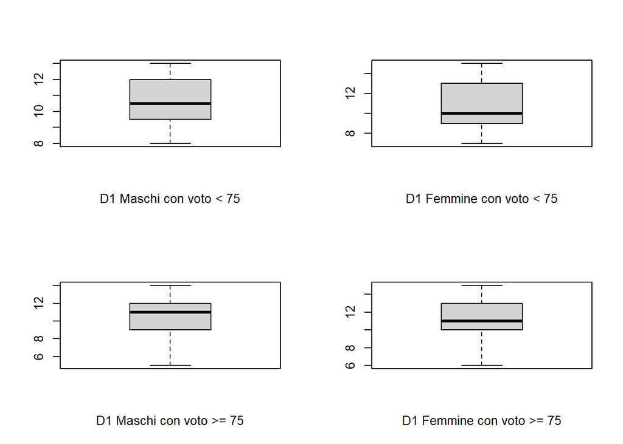

```r
par(mfrow=c(2,2))
boxplot(datitest$D1[datitest$SESSO==1 & datitest$VOTO<75],xlab="D1 Maschi con voto < 75")

boxplot(datitest$D1[datitest$SESSO==2 & datitest$VOTO<75],xlab="D1 Femmine con voto < 75")

boxplot(datitest$D1[datitest$SESSO==1 & datitest$VOTO>=75],xlab="D1 Maschi con voto >= 75")

boxplot(datitest$D1[datitest$SESSO==2 & datitest$VOTO>=75],xlab="D1 Femmine con voto >= 75")
```

18. Creare una nuova variabile `PTOT` contenente il punteggio complessivo (calcolato come somma dei singoli test D1, …, D4) per ogni studente.

```r
datitest$PTOT = apply(datitest[, c("D1", "D2", "D3", "D4")], 1, sum)
# la funzione rowSums() avrebbe prodotto lo stesso risultato
# datitest$PTOT = rowSums(datitest[, c("D1", "D2", "D3", "D4")])
```

19. Creare una nuova variabile `PTOTc` che contiene il punteggio totale PTOT corretto per il voto di diploma secondo la seguente formula:

$$PTOTc = PTOT \times \log_2\left(\frac{100}{VOTO}\right)$$

```r
datitest$PTOTc <- datitest$PTOT*log2(100/datitest$VOTO)

datitest$PTOTc
```

```
 [1] 25.996474 12.877124 22.534967  2.146017  4.920777 18.644651 27.267727
 [8]  0.000000 15.045290  0.000000 15.082786  7.634682 22.534967 29.478624
[15]  3.952080 20.635037 12.877124 21.752093 10.375937 26.896735 21.413269
[22]  6.454860  7.565524  2.179066  8.440749 10.623627 13.842908 33.900417
[29]  9.378610  0.000000 14.526312 16.691800 14.328647  9.139770 11.738472
[36]  5.472111  9.979771 18.244919 20.981172  0.000000 21.246690 12.187435
[43]  9.448038  7.043085 18.010061  1.669847 29.478624  5.320108 11.911340
[50] 13.144575 24.827756  0.000000 16.345139  5.306400 14.696613 16.072904
[57]  0.000000  8.244441 15.437075 12.242716  4.090004 19.982530  2.960023
[64] 10.623627 10.313089 21.955146 17.846612 26.530761  8.036508 27.098516
```

20. Visualizzare il grafico di dispersione tra VOTO e PTOT. Il grafico può essere ottenuto con la funzione `plot(X, Y)`, dove X è la variabile che si vuole rappresentare sul grafico delle X e Y la variabile che si vuole rappresentare sull’asse delle Y.

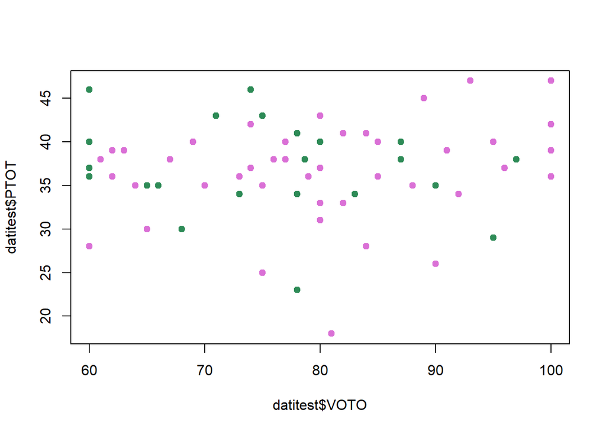

```r
par(mfrow=c(1,1))
plot(datitest$VOTO, datitest$PTOT, pch = 19,
     col = ifelse(datitest$SESSO == 1, "seagreen", "orchid"))
```

21. Ripetere la procedura utilizzando PTOTc al posto di PTOT.

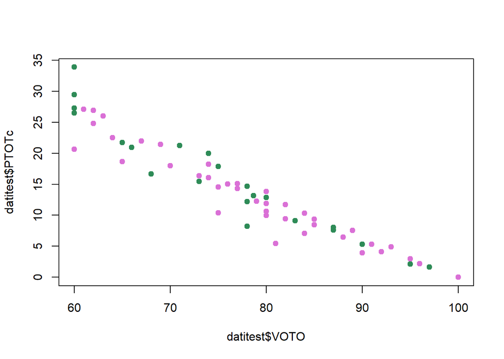

```r
plot(datitest$VOTO, datitest$PTOTc, pch = 19,
     col = ifelse(datitest$SESSO == 1, "seagreen", "orchid"))
```